# Modelling the distribution of biodiversity under global climate change

Jorge Assis, PhD // Nord University, Norway // biodiversityDS, Centre of Marine Sciences, Portugal

## Vector data

## Importing and ploting vector data

biodiversityDS .

Vector data are composed of **vertices** - point in space (e.g., longitude and latitude) - that define the shape of the spatial object. The segments that connect vertices determine the type of vector: **points**, **lines** and **polygons**.

**Vector point data** can be stored in regular **text delimited files**. When imported to R using the **read.table** function they are stored as a **data.frame** object.

```r
# open vector point from text delimited file
distributionRecords <- read.table("../Data/Text delimited/species_presence_records.csv", sep = ";",
    header = TRUE)
```

```r
# inspect the top records of the data.frame
head(distributionRecords)
```

| Lon | Lat |
| --- | --- |
| 11.080359 | 42.41853 |
| 10.836515 | 42.31011 |
| 15.469765 | 42.06097 |
| 3.297701 | 42.04394 |

S2 // R as a Geographic Information System

biodiversityDS .

A **data.frame** with **longitude and latitude** records can be mapped directly with the **plot** function (i.e., xy plot).

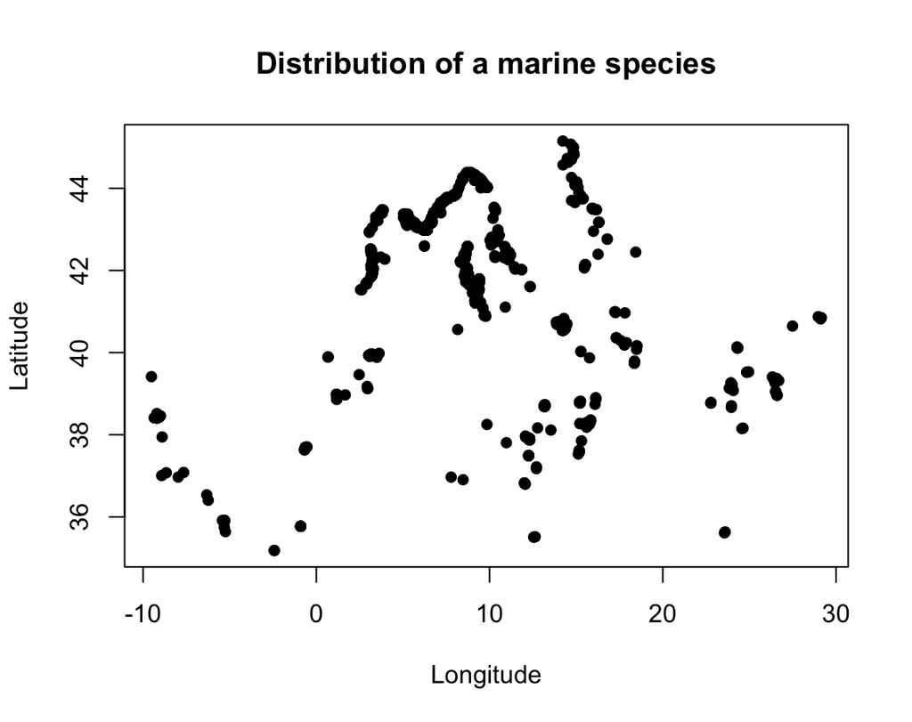

```r
# plot distribution records from a data.frame (black points and labels are added)
plot(distributionRecords, main = "Distribution of a marine species", col = "Black", pch = 16,
    ylab = "Latitude", xlab = "Longitude")
```

S2 // R as a Geographic Information System

biodiversityDS .

To transform a **data.frame** into a **spatial object** (i.e., vector data) we can use the **terra** package. A spatial object is an object ready for vector operations.

```r
# inspect the class of the object
class(distributionRecords)
```

```
## [1] "data.frame"
```

```r
# load terra package
library(terra)
# transform data.frame into a spatial object (providing the Geographic coordinate system)
distributionRecords <- vect(distributionRecords, geom = c("Lon", "Lat"), crs = "EPSG:4326")
# inspect the new class of the object
class(distributionRecords)
```

```
## [1] "SpatVector"
## attr(,"package")
## [1] "terra"
```

biodiversityDS .

Vector data are commonly in a **ESRI shapefile** format. The packages **sf** and **terra** deal with shapefiles.

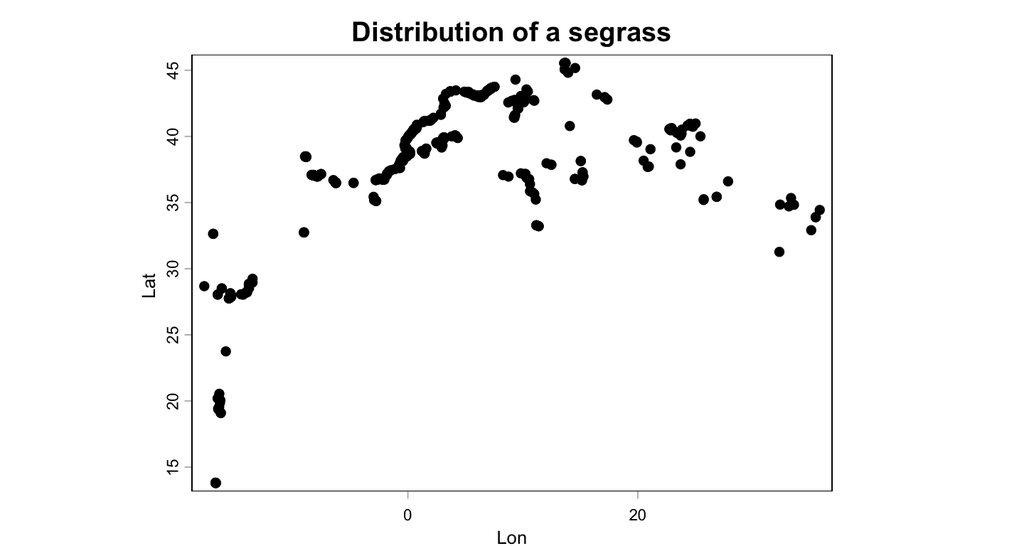

```r
# load terra package
library(terra)
# load a point vector shapefile with terra package
distributionRecords <- vect("../Data/Vector data/Seagrass distribution/cymodocea_nodosa.shp")
# plot point data
plot(distributionRecords, main = "Distribution of a segrass", col = "Black", ylab = "Lat", xlab = "Lon")
```

S2 // R as a Geographic Information System

biodiversityDS .

Vector data are migrating to **GeoPackage** format. The packages **sf** and **terra** deal with shapefiles.

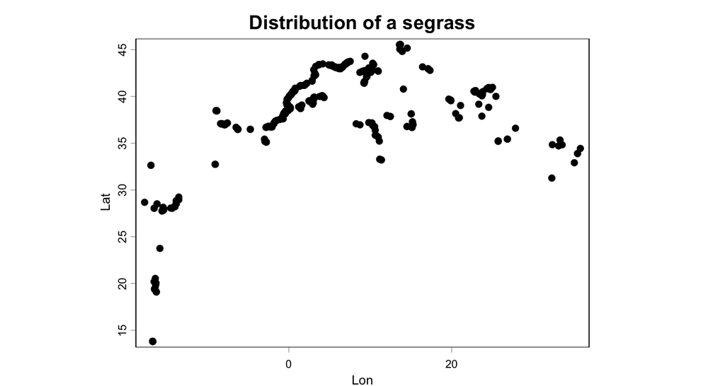

```r
# load a point vector shapefile with terra package
distributionRecords <- vect("../Data/Vector data/Seagrass distribution/cymodocea_nodosa.gpkg")
# plot point data
plot(distributionRecords, main = "Distribution of a segrass", col = "Black", ylab = "Lat", xlab = "Lon")
```

S2 // R as a Geographic Information System

biodiversityDS .

In R, the attributes of vector data are stored as a **data.frame**. Each row is a vector element (e.g., point, line, polygon) and each column is an attribute (e.g., date, locality, taxonomy, etc.)

```r
# show attributes of vector data
head(distributionRecords)
```

| year | month | day | country | localty | kingdom | phylum | class | order | family | genus |
| --- | --- | --- | --- | --- | --- | --- | --- | --- | --- | --- |
| 2005 | 7 | NA | Greece | Eleftheron gulf | Plantae | Tracheophyta | Magnoliopsida | Alismatales | Cymodoceaceae | Cymodocea |
| 2005 | 7 | NA | Greece | Biamyl | Plantae | Tracheophyta | Magnoliopsida | Alismatales | Cymodoceaceae | Cymodocea |
| 2004 | 7 | NA | Greece | Nea karvali | Plantae | Tracheophyta | Magnoliopsida | Alismatales | Cymodoceaceae | Cymodocea |
| 2004 | 7 | NA | Greece | Erateino | Plantae | Tracheophyta | Magnoliopsida | Alismatales | Cymodoceaceae | Cymodocea |
| 2004 | 7 | NA | Greece | Agiasma | Plantae | Tracheophyta | Magnoliopsida | Alismatales | Cymodoceaceae | Cymodocea |

S2 // R as a Geographic Information System

biodiversityDS .

Such like point data, **vector line data** are commonly stored in a **ESRI shapefile** format.

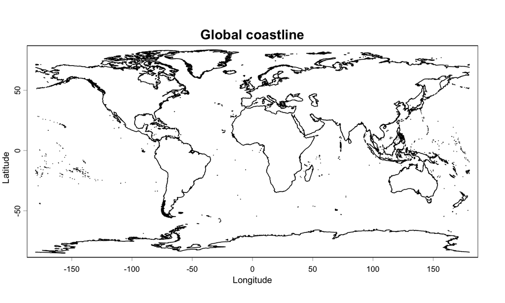

```r
# load a line vector shapefile with terra package
coastline <- vect("../Data/Vector data/Coastline/coastline.shp")
# plot spatial line vector
plot(coastline, main = "Global coastline", col = "black", axes = TRUE, ylab = "Latitude", xlab = "Longitude")
```

S2 // R as a Geographic Information System

biodiversityDS .

**Vector polygon data** are also commonly stored in a **ESRI shapefile** format.

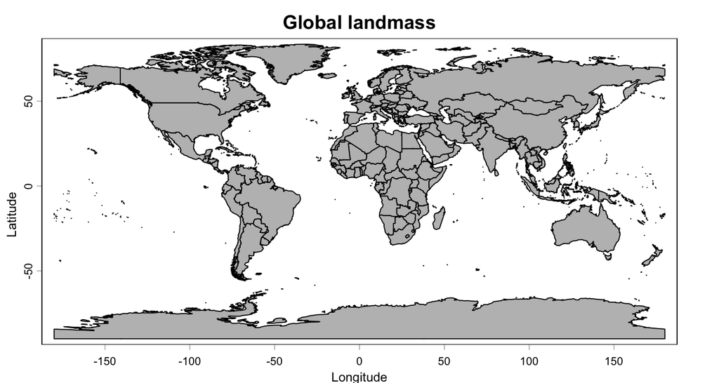

```r
# load a polygon vector shapefile with terra package
landmass <- vect("../Data/Vector data/Landmass/landmass.shp")
# plot spatial polygon vector with a title
plot(landmass, main = "Global landmass", col = "gray", border = "black", axes = TRUE, ylab = "Latitude",
    xlab = "Longitude")
```

S2 // R as a Geographic Information System

biodiversityDS .

The **add=TRUE** argument can be used to **overlay multiple vectors**.

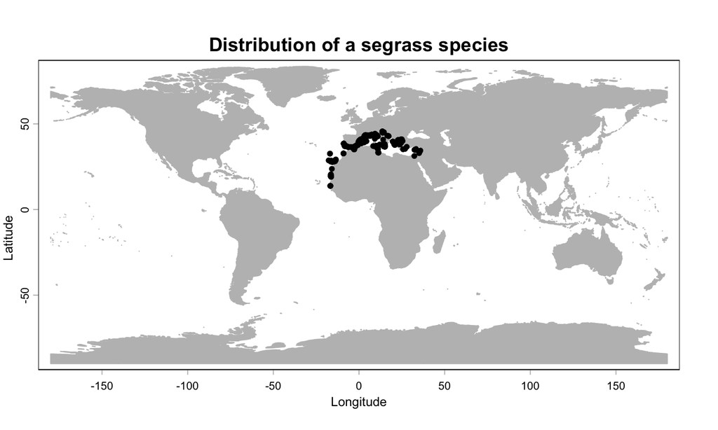

```r
plot(landmass, main = "Distribution of a segrass species", col = "Gray", border = "Gray", axes = TRUE,
    ylab = "Latitude", xlab = "Longitude")
plot(distributionRecords, col = "Black", pch = 20, size = 0.25, add = TRUE)
```

S2 // R as a Geographic Information System

## Better maps with ggplot and tidyterra

biodiversityDS .

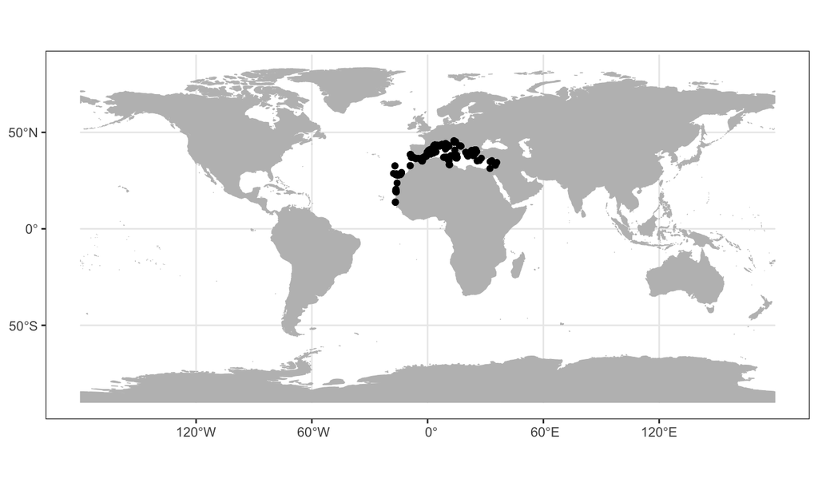

```r
library(ggplot2)
library(tidyterra)
ggplot() + geom_spatvector(data = landmass, fill = "gray", color = "gray") + geom_spatvector(data = distributionRecords,
    color = "black", size = 1.5) + theme_bw()
```

S2 // R as a Geographic Information System

biodiversityDS .

Changing the coordinate reference system (e.g., equal area) and removing the panel border to improve the aesthetics of the plot.

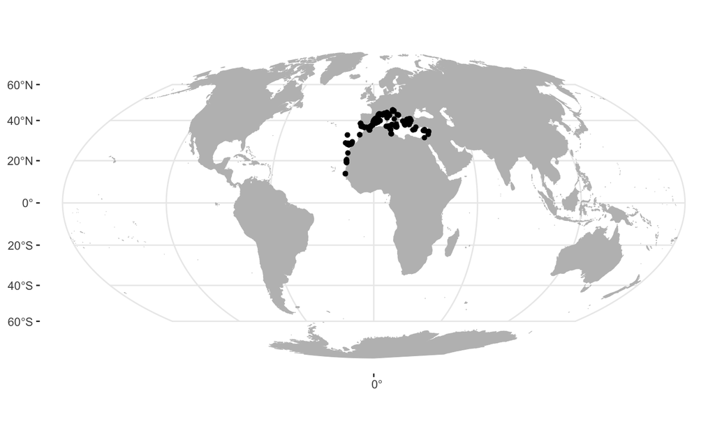

```r
ggplot() + geom_spatvector(data = landmass, fill = "gray", color = "gray") + geom_spatvector(data = distributionRecords,
    color = "black", size = 1.25) + theme_bw() + coord_sf(crs = "+proj=moll") + theme(panel.border = element_blank())
```

S2 // R as a Geographic Information System

biodiversityDS .

Adding relevant information to the plot (e.g., labels).

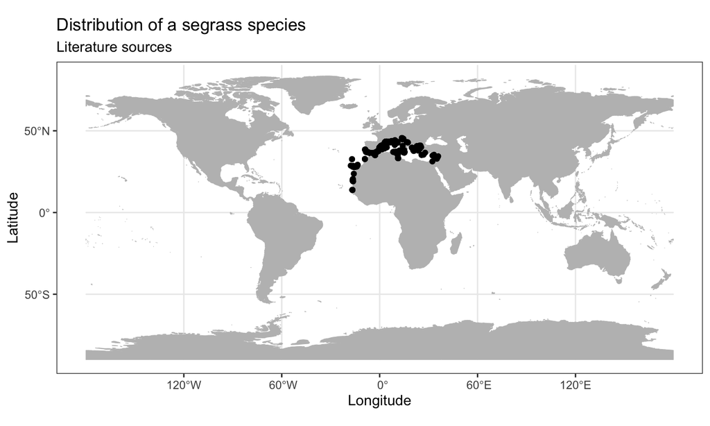

```r
ggplot() + geom_spatvector(data = landmass, fill = "gray", color = "gray") + geom_spatvector(data = distributionRecords,
    color = "black", size = 1.5) + labs(title = "Distribution of a segrass species", subtitle = "Literature sources") +
    xlab("Longitude") + ylab("Latitude") + theme_bw()
```

S2 // R as a Geographic Information System

biodiversityDS .

#### Challenge 2.1

The main objective of this challenge is to **map** the distribution of a seagrass species based on a ESRI shapefile. For context, the plot must include the global landmass.

**Packages, files and functions to accomplish the challenge:**

**Functions to use**  
library  
vect  
plot OR ggplot  
**Files to use**  
"cymodocea_nodosa.shp"  
"landmass.shp"

S2 // R as a Geographic Information System

## Conversion between spatial object formats

biodiversityDS .

Some operations are only available for a specific format (i.e., **sf** or **terra**). Spatial objects can be converted between formats.

```r
# load a polygon vector shapefile with terra package and inspect its class
landmass <- vect("../Data/Vector data/Landmass/landmass.shp")
class(landmass)
```

```
## [1] "SpatVector"
## attr(,"package")
## [1] "terra"
```

```r
# load sf package
library(sf)
# convert terra object to sf object and inspect its class
landmass <- st_as_sf(landmass)
class(landmass)
```

```
## [1] "sf"         "data.frame"
```

S2 // R as a Geographic Information System

biodiversityDS .

```r
# load a polygon vector shapefile with sf package and inspect its class
landmass <- st_read("../Data/Vector data/Landmass/landmass.shp", quiet = TRUE)
class(landmass)
```

```
## [1] "sf"         "data.frame"
```

```r
# convert sf object to terra object and inspect its class
landmass <- vect(landmass)
class(landmass)
```

```
## [1] "SpatVector"
## attr(,"package")
## [1] "terra"
```

S2 // R as a Geographic Information System

## Generate vector data in R

biodiversityDS .

To generate (i.e., to draw) vector data in R we can use the **drawFeatures** function from package **mapedit**.  
To give geographic context, a global map can be added with the **leaflet** package.

```r
# Load necessary libraries
library(leaflet)
library(mapedit)

# create a base leaflet map
baseMap <- leaflet()
baseMap <- addTiles(baseMap)

# drawing vector polygon in the Viewer pane
drawnFeatures <- drawFeatures(baseMap)
```

S2 // R as a Geographic Information System

biodiversityDS .

[figure not shown]

In the Viewer pane a tool is shown to generate vector data. The tool will generate an **sf** object.

```r
# navigate the map and use the polygon tool to a draw vector; click to create vertices,
# click first point or click 'finish' to close the polygon; click 'Done' button in the map
# interface when done drawing all features; type 'Esc' to quit the tool at any time.
```

S2 // R as a Geographic Information System

## Exporting vector data

biodiversityDS .

Spatial data can be exported to multiple GIS standard formats, such as ESRI shapefile or GeoPackage.

ESRI shapefile, a format with distinct files storing geographic location and associated attribute information.

```r
# export vector data to shapefile
writeVector(x = landmass, filename = "directory/output_name.shp", filetype = "ESRI Shapefile",
    overwrite = TRUE)
```

GeoPackage, defined by a unique spatial database file.

```r
# export vector data to GeoPackage
writeVector(x = landmass, filename = "directory/output_name.gpkg", filetype = "GPKG", overwrite = TRUE)
```

S2 // R as a Geographic Information System

biodiversityDS .

#### Challenge 2.2

The main objective of this challenge is to **generate** vector data in R and **export** it as an ESRI shapefile.

**Packages, files and functions to accomplish the challenge:**

**Functions to use**  
library  
leaflet  
addTiles  
drawFeatures  
vect  
plot  
writeVector

S2 // R as a Geographic Information System

## Vector data operations that change the geometry of spatial objects

biodiversityDS .

#### Crop vector data to a different extent

Crop subsets data to a region of interest - the extent, which can be defined by a polygon or a bounding box.

```r
# read landmass from an R package
landmass <- vect("../Data/Vector data/Landmass/landmass.shp")
class(landmass)
```

```
## [1] "SpatVector"
## attr(,"package")
## [1] "terra"
```

```r
# generate an extent object (region of interest, order: xmin, xmax, ymin, ymax)
mediterraneanExtent <- ext(-15, 45, 30, 47.5)
class(mediterraneanExtent)
```

```
## [1] "SpatExtent"
## attr(,"package")
## [1] "terra"
```

S2 // R as a Geographic Information System

biodiversityDS .

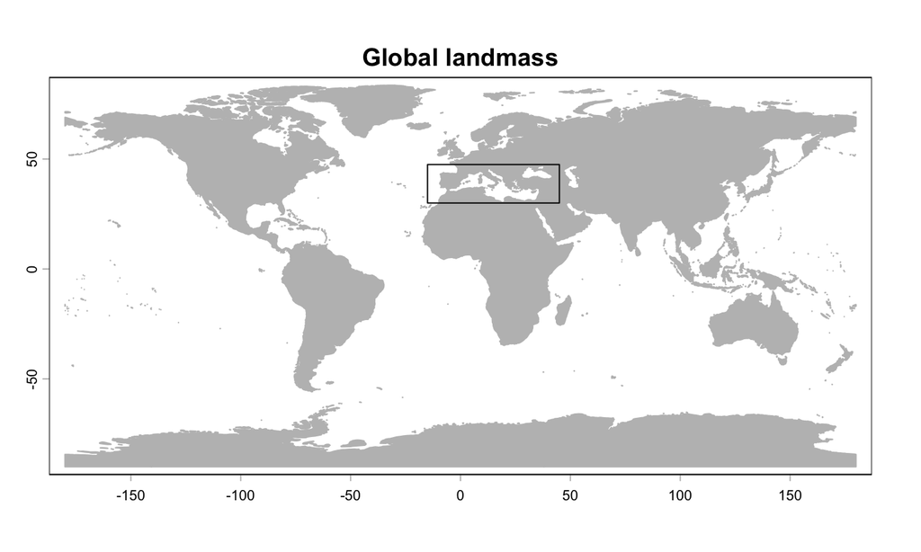

```r
# for inspection, plot the landmass and the extent region
plot(landmass, main = "Global landmass", col = "gray", border = "gray", axes = TRUE)
plot(mediterraneanExtent, border = "black", add = TRUE)
```

S2 // R as a Geographic Information System

biodiversityDS .

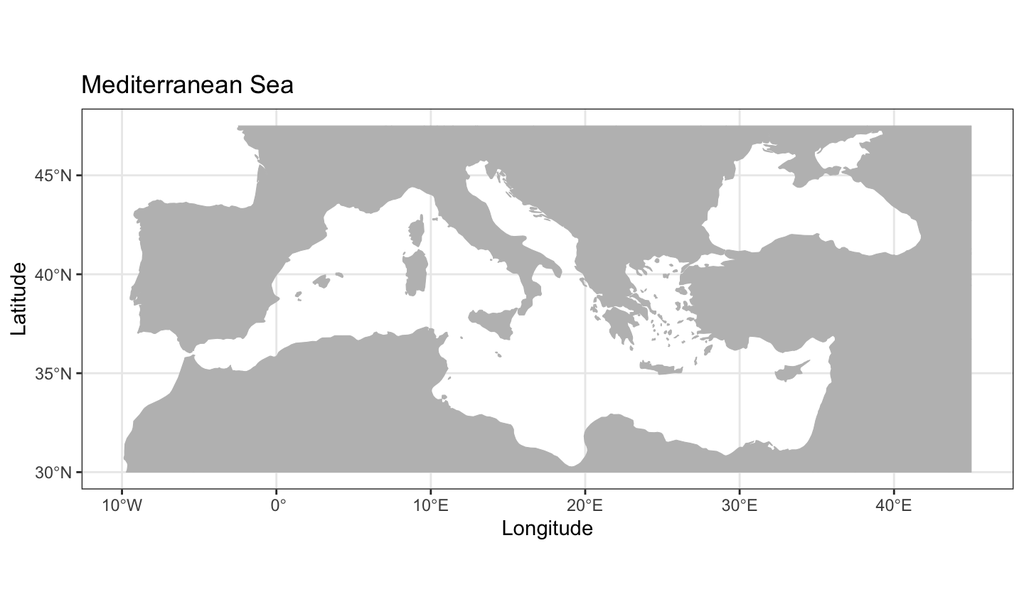

```r
# crop the landmass to the extent of the Mediterranean Sea
mediterraneanLandmass <- crop(landmass, mediterraneanExtent)

ggplot() + geom_spatvector(data = mediterraneanLandmass, fill = "gray", color = "gray") + labs(title = "Mediterranean Sea") +
    xlab("Longitude") + ylab("Latitude") + theme_bw()
```

S2 // R as a Geographic Information System

#### Challenge 2.3

The main objective of this challenge is to **crop** a global map to the Azores region and **plot** it.

**Packages, files and functions to accomplish the challenge:**

**Information**  
(min longitude: -36, max longitude: -18, min latitude: 34, max latitude: 42)  
**Files to use**  
"landmass.shp"  
**Functions to use**  
library  
vect  
ext  
crop  
plot

S2 // R as a Geographic Information System

## Raster data

## Raster data

biodiversityDS .

Raster data uses a regular grid to represent a spatial gradient. The **terra** package deals with raster data.

```r
# load libraries
library(terra)
# Open a raster layer with the global sea surface temperature
seaSurfaceTemp <- rast("../Data/Raster data/Present Surface OceanTemperature LtMax.tif")
# inspect the raster object
seaSurfaceTemp
```

```
## class       : SpatRaster
## size        : 3600, 7200, 1  (nrow, ncol, nlyr)
## resolution  : 0.05, 0.05  (x, y)
## extent      : -180, 180, -90, 90  (xmin, xmax, ymin, ymax)
## coord. ref. : lon/lat WGS 84 (EPSG:4326)
## source      : Present Surface OceanTemperature LtMax.tif
## name        : Present Surface OceanTemperature LtMax
## min value   :                              -1.846673
## max value   :                              34.883312
```

S2 // R as a Geographic Information System

## Plotting raster data

biodiversityDS .

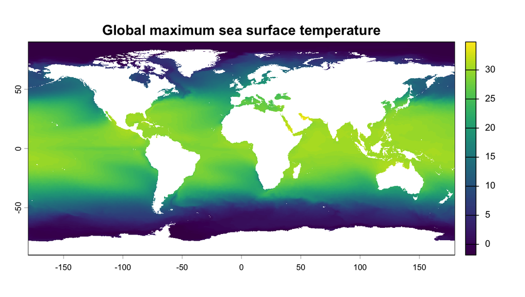

```r
# Plot a raster layer
plot(seaSurfaceTemp, main = "Global maximum sea surface temperature")
```

S2 // R as a Geographic Information System

## Plotting raster data

biodiversityDS .

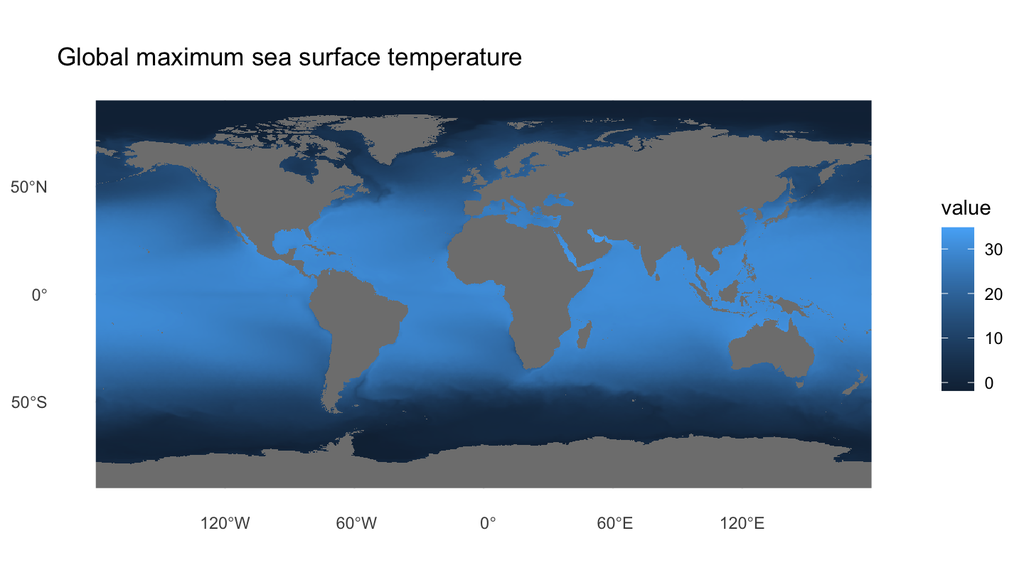

```r
ggplot() + geom_spatraster(data = seaSurfaceTemp) + labs(title = "Global maximum sea surface temperature") +
    theme_minimal()
```

S2 // R as a Geographic Information System

## Plotting raster data

biodiversityDS .

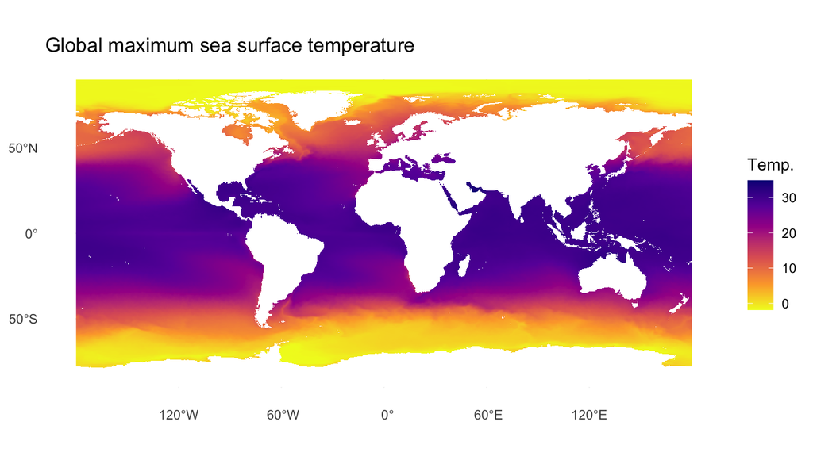

```r
ggplot() + geom_spatraster(data = seaSurfaceTemp) + labs(title = "Global maximum sea surface temperature",
    fill = "Temp.") + scale_fill_viridis_c(option = "plasma", direction = -1, na.value = "white") +
    theme_minimal()
```

S2 // R as a Geographic Information System

## Combining different rasters

biodiversityDS .

Combining different raster layers into a unique object. These must have the same extent and resolution.

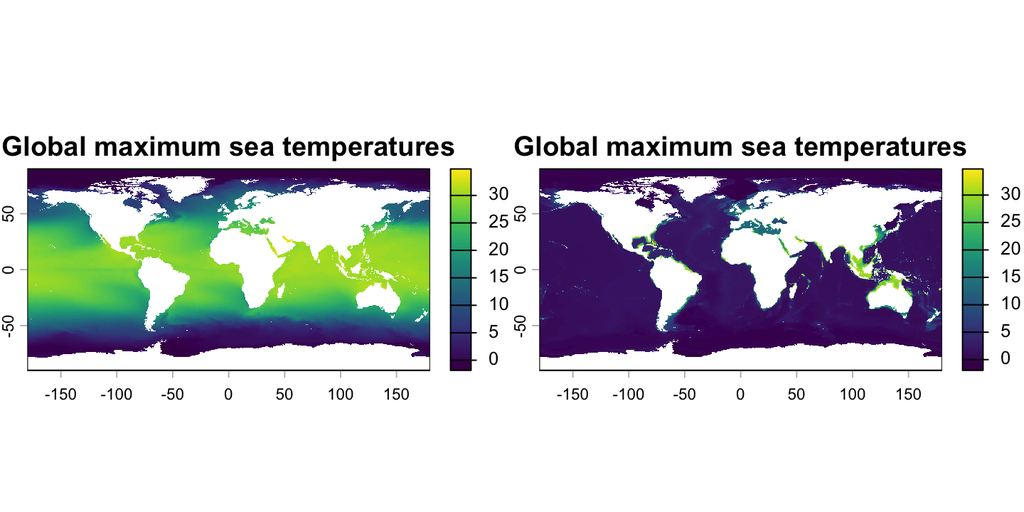

```r
# Open a raster layer with the global sea surface temperature
seaSurfaceTemp <- rast("../Data/Raster data/Present Surface OceanTemperature LtMax.tif")
# Open a raster layer with the global bottom surface temperature
seaBottomTemp <- rast("../Data/Raster data/Present Benthic OceanTemperature LtMax.tif")
# combine the raster layers
seaTemp <- c(seaSurfaceTemp, seaBottomTemp)
# Plot the raster layers
plot(seaTemp, axes = TRUE, main = "Global maximum sea temperatures")
```

biodiversityDS .

Combining different raster layers into a unique object, **directly from file vector**.

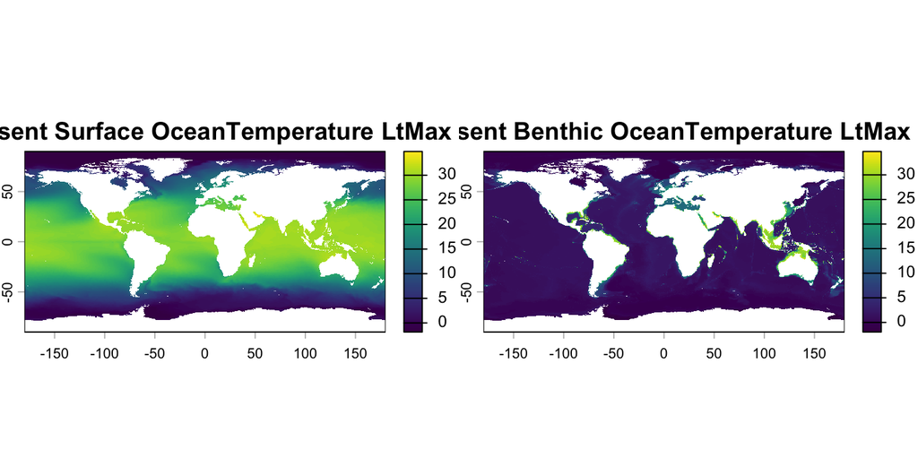

```r
# create a vector with the path to the raster layers
file1 <- "../Data/Raster data/Present Surface OceanTemperature LtMax.tif"
file2 <- "../Data/Raster data/Present Benthic OceanTemperature LtMax.tif"
myFiles <- c(file1, file2)
# combine the raster layers
seaTemp <- rast(myFiles)
# plot the raster layers
plot(seaTemp)
```

S2 // R as a Geographic Information System

## Subsetting combined raster data

biodiversityDS .

```r
# create a vector with the path to the raster layers
myFiles <- c("../Data/Raster data/Present Surface OceanTemperature LtMax.tif", "../Data/Raster data/Present Benthic OceanTemperature LtMax.tif",
    "../Data/Raster data/Present Surface Nitrate Mean.tif", "../Data/Raster data/Bathymetry.tif")
# combining the raster layers
environmentLayers <- rast(myFiles)
# inspect the combined raster layers raster layers
names(environmentLayers)
```

```
## [1] "Present Surface OceanTemperature LtMax"
## [2] "Present Benthic OceanTemperature LtMax"
## [3] "Present Surface Nitrate Mean"
## [4] "Bathymetry"
```

S2 // R as a Geographic Information System

biodiversityDS .

To subset combined raster layers use the **subset** function or work with **indices**.

```r
# subset the combined raster layers
environmentLayersSubset <- subset(environmentLayers, c(1, 3))
# inspect the combined raster layers
names(environmentLayersSubset)
```

```
## [1] "Present Surface OceanTemperature LtMax"
## [2] "Present Surface Nitrate Mean"
```

```r
# subset the combined raster layers (note the double brackets)
environmentLayersSubset <- environmentLayers[[c(1, 3)]]
# inspect the combined raster layers
names(environmentLayersSubset)
```

```
## [1] "Present Surface OceanTemperature LtMax"
## [2] "Present Surface Nitrate Mean"
```

S2 // R as a Geographic Information System